# Risk Factor Analysis

## Outcome Variable

**Outcome Variable:** ever_wasted

## Predictor Variables

**Intervention Variable:** nrooms

**Adjustment Set:**

unadjusted

## Stratifying Variables

The analysis was stratified on these variable(s):

- agecat
- studyid
- country

## Data Summary

| agecat | studyid | country | nrooms | ever_wasted | n_cell | n |
| --- | --- | --- | --- | --- | --- | --- |
| 0-24 months | CMC-V-BCS-2002 | INDIA | 4+ | 0 | 9 | 373 |
| 0-24 months | CMC-V-BCS-2002 | INDIA | 4+ | 1 | 5 | 373 |
| 0-24 months | CMC-V-BCS-2002 | INDIA | 1 | 0 | 68 | 373 |
| 0-24 months | CMC-V-BCS-2002 | INDIA | 1 | 1 | 134 | 373 |
| 0-24 months | CMC-V-BCS-2002 | INDIA | 2 | 0 | 43 | 373 |
| 0-24 months | CMC-V-BCS-2002 | INDIA | 2 | 1 | 63 | 373 |
| 0-24 months | CMC-V-BCS-2002 | INDIA | 3 | 0 | 25 | 373 |
| 0-24 months | CMC-V-BCS-2002 | INDIA | 3 | 1 | 26 | 373 |
| 0-24 months | COHORTS | INDIA | 4+ | 0 | 90 | 5366 |
| 0-24 months | COHORTS | INDIA | 4+ | 1 | 16 | 5366 |
| 0-24 months | COHORTS | INDIA | 1 | 0 | 2235 | 5366 |
| 0-24 months | COHORTS | INDIA | 1 | 1 | 1276 | 5366 |
| 0-24 months | COHORTS | INDIA | 2 | 0 | 1089 | 5366 |
| 0-24 months | COHORTS | INDIA | 2 | 1 | 465 | 5366 |
| 0-24 months | COHORTS | INDIA | 3 | 0 | 152 | 5366 |
| 0-24 months | COHORTS | INDIA | 3 | 1 | 43 | 5366 |
| 0-24 months | CONTENT | PERU | 4+ | 0 | 75 | 215 |
| 0-24 months | CONTENT | PERU | 4+ | 1 | 3 | 215 |
| 0-24 months | CONTENT | PERU | 1 | 0 | 42 | 215 |
| 0-24 months | CONTENT | PERU | 1 | 1 | 2 | 215 |
| 0-24 months | CONTENT | PERU | 2 | 0 | 54 | 215 |
| 0-24 months | CONTENT | PERU | 2 | 1 | 0 | 215 |
| 0-24 months | CONTENT | PERU | 3 | 0 | 39 | 215 |
| 0-24 months | CONTENT | PERU | 3 | 1 | 0 | 215 |
| 0-24 months | GMS-Nepal | NEPAL | 4+ | 0 | 116 | 686 |
| 0-24 months | GMS-Nepal | NEPAL | 4+ | 1 | 198 | 686 |
| 0-24 months | GMS-Nepal | NEPAL | 1 | 0 | 22 | 686 |
| 0-24 months | GMS-Nepal | NEPAL | 1 | 1 | 27 | 686 |
| 0-24 months | GMS-Nepal | NEPAL | 2 | 0 | 68 | 686 |
| 0-24 months | GMS-Nepal | NEPAL | 2 | 1 | 75 | 686 |

[output cut: 306 more lines]

The following strata were considered:

- agecat: 0-24 months, studyid: CMC-V-BCS-2002, country: INDIA
- agecat: 0-24 months, studyid: COHORTS, country: INDIA
- agecat: 0-24 months, studyid: CONTENT, country: PERU
- agecat: 0-24 months, studyid: GMS-Nepal, country: NEPAL
- agecat: 0-24 months, studyid: IRC, country: INDIA
- agecat: 0-24 months, studyid: MAL-ED, country: BANGLADESH
- agecat: 0-24 months, studyid: MAL-ED, country: BRAZIL
- agecat: 0-24 months, studyid: MAL-ED, country: INDIA
- agecat: 0-24 months, studyid: MAL-ED, country: NEPAL
- agecat: 0-24 months, studyid: MAL-ED, country: PERU
- agecat: 0-24 months, studyid: MAL-ED, country: SOUTH AFRICA
- agecat: 0-24 months, studyid: MAL-ED, country: TANZANIA, UNITED REPUBLIC OF
- agecat: 0-24 months, studyid: NIH-Crypto, country: BANGLADESH
- agecat: 0-24 months, studyid: PROVIDE, country: BANGLADESH
- agecat: 0-6 months, studyid: CMC-V-BCS-2002, country: INDIA
- agecat: 0-6 months, studyid: COHORTS, country: INDIA
- agecat: 0-6 months, studyid: CONTENT, country: PERU
- agecat: 0-6 months, studyid: GMS-Nepal, country: NEPAL
- agecat: 0-6 months, studyid: IRC, country: INDIA
- agecat: 0-6 months, studyid: MAL-ED, country: BANGLADESH
- agecat: 0-6 months, studyid: MAL-ED, country: BRAZIL
- agecat: 0-6 months, studyid: MAL-ED, country: INDIA
- agecat: 0-6 months, studyid: MAL-ED, country: NEPAL
- agecat: 0-6 months, studyid: MAL-ED, country: PERU
- agecat: 0-6 months, studyid: MAL-ED, country: SOUTH AFRICA
- agecat: 0-6 months, studyid: MAL-ED, country: TANZANIA, UNITED REPUBLIC OF
- agecat: 0-6 months, studyid: NIH-Crypto, country: BANGLADESH
- agecat: 0-6 months, studyid: PROVIDE, country: BANGLADESH
- agecat: 6-24 months, studyid: CMC-V-BCS-2002, country: INDIA
- agecat: 6-24 months, studyid: COHORTS, country: INDIA
- agecat: 6-24 months, studyid: CONTENT, country: PERU
- agecat: 6-24 months, studyid: GMS-Nepal, country: NEPAL
- agecat: 6-24 months, studyid: IRC, country: INDIA
- agecat: 6-24 months, studyid: MAL-ED, country: BANGLADESH
- agecat: 6-24 months, studyid: MAL-ED, country: BRAZIL
- agecat: 6-24 months, studyid: MAL-ED, country: INDIA
- agecat: 6-24 months, studyid: MAL-ED, country: NEPAL
- agecat: 6-24 months, studyid: MAL-ED, country: PERU
- agecat: 6-24 months, studyid: MAL-ED, country: SOUTH AFRICA
- agecat: 6-24 months, studyid: MAL-ED, country: TANZANIA, UNITED REPUBLIC OF
- agecat: 6-24 months, studyid: NIH-Crypto, country: BANGLADESH
- agecat: 6-24 months, studyid: PROVIDE, country: BANGLADESH

### Dropped Strata

Some strata were dropped due to rare outcomes:

- agecat: 0-24 months, studyid: CONTENT, country: PERU
- agecat: 0-24 months, studyid: MAL-ED, country: BANGLADESH
- agecat: 0-24 months, studyid: MAL-ED, country: BRAZIL
- agecat: 0-24 months, studyid: MAL-ED, country: PERU
- agecat: 0-24 months, studyid: MAL-ED, country: SOUTH AFRICA
- agecat: 0-24 months, studyid: MAL-ED, country: TANZANIA, UNITED REPUBLIC OF
- agecat: 0-6 months, studyid: CMC-V-BCS-2002, country: INDIA
- agecat: 0-6 months, studyid: CONTENT, country: PERU
- agecat: 0-6 months, studyid: MAL-ED, country: BANGLADESH
- agecat: 0-6 months, studyid: MAL-ED, country: BRAZIL
- agecat: 0-6 months, studyid: MAL-ED, country: NEPAL
- agecat: 0-6 months, studyid: MAL-ED, country: PERU
- agecat: 0-6 months, studyid: MAL-ED, country: SOUTH AFRICA
- agecat: 0-6 months, studyid: MAL-ED, country: TANZANIA, UNITED REPUBLIC OF
- agecat: 6-24 months, studyid: CMC-V-BCS-2002, country: INDIA
- agecat: 6-24 months, studyid: COHORTS, country: INDIA
- agecat: 6-24 months, studyid: CONTENT, country: PERU
- agecat: 6-24 months, studyid: MAL-ED, country: BANGLADESH
- agecat: 6-24 months, studyid: MAL-ED, country: BRAZIL
- agecat: 6-24 months, studyid: MAL-ED, country: INDIA
- agecat: 6-24 months, studyid: MAL-ED, country: NEPAL
- agecat: 6-24 months, studyid: MAL-ED, country: PERU
- agecat: 6-24 months, studyid: MAL-ED, country: SOUTH AFRICA
- agecat: 6-24 months, studyid: MAL-ED, country: TANZANIA, UNITED REPUBLIC OF
- agecat: 6-24 months, studyid: PROVIDE, country: BANGLADESH

## Methods Detail

We’re interested in the causal parameters $E[Y_a]$ for all values of $a \in \mathcal{A}$. These parameters represent the mean outcome if, possibly contrary to fact, we intervened to set all units to have $A=a$. Under the randomization and positivity assumptions, these are identified by the statistical parameters $\psi_a=E_W[E_{Y|A,W}(Y|A=a,W)]$. In addition, we’re interested in the mean of $Y$, $E[Y]$ under no intervention (the observed mean). We will estimate these parameters by using SuperLearner to fit the relevant likelihood factors – $E_{Y|A,W}(Y|A=a,W)$ and $p(A=a|W)$, and then updating our likelihood fit using a joint TMLE.

For unadjusted analyses ($W=\{\}$), initial likelihoods were estimated using Lrnr_glm to estimate the simple $E(Y|A)$ and Lrnr_mean to estimate $p(A)$. For adjusted analyses, a small library containing Lrnr_glmnet, Lrnr_xgboost, and Lrnr_mean was used.

Having estimated these parameters, we will then use the delta method to estimate relative risks and attributable risks relative to a prespecified baseline level of $A$.

# Results Detail

## Results Plots

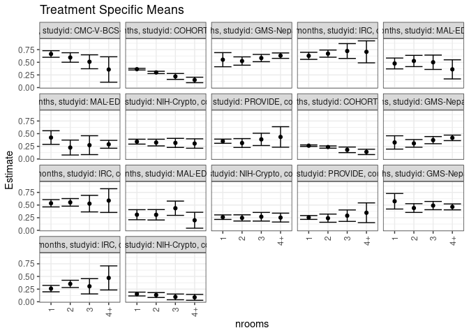

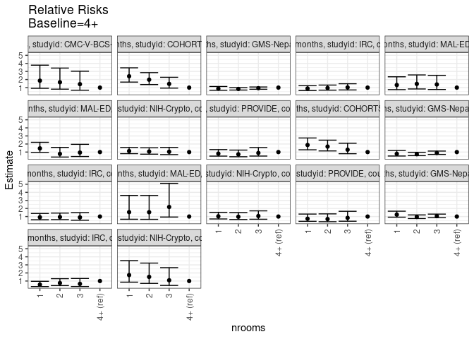

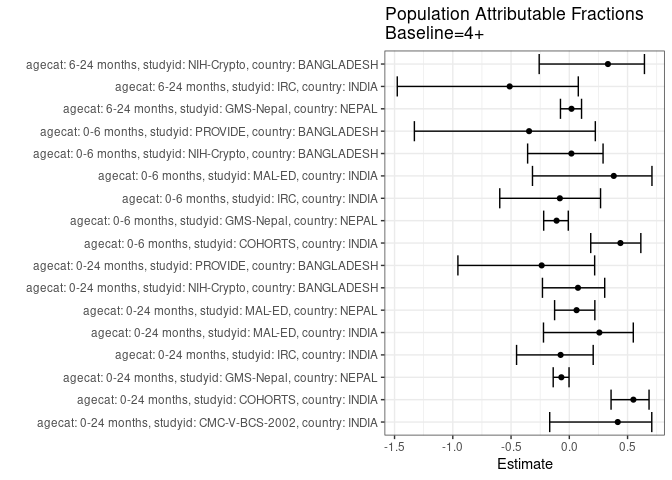

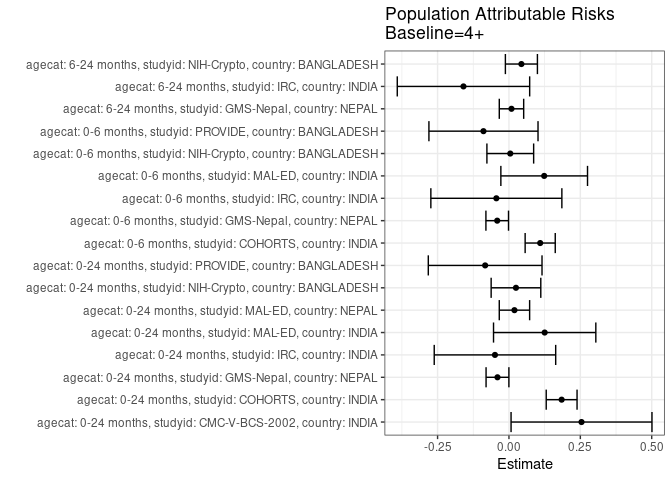

## Results Table

### Parameter: TSM

| agecat | studyid | country | intervention_level | baseline_level | estimate | ci_lower | ci_upper |
| --- | --- | --- | --- | --- | --- | --- | --- |
| 0-24 months | CMC-V-BCS-2002 | INDIA | 4+ | NA | 0.3571429 | 0.1058123 | 0.6084734 |
| 0-24 months | CMC-V-BCS-2002 | INDIA | 1 | NA | 0.6633663 | 0.5981118 | 0.7286209 |
| 0-24 months | CMC-V-BCS-2002 | INDIA | 2 | NA | 0.5943396 | 0.5007394 | 0.6879398 |
| 0-24 months | CMC-V-BCS-2002 | INDIA | 3 | NA | 0.5098039 | 0.3724211 | 0.6471867 |
| 0-24 months | COHORTS | INDIA | 4+ | NA | 0.1509434 | 0.0970884 | 0.2047984 |
| 0-24 months | COHORTS | INDIA | 1 | NA | 0.3634292 | 0.3475179 | 0.3793406 |
| 0-24 months | COHORTS | INDIA | 2 | NA | 0.2992278 | 0.2764584 | 0.3219972 |
| 0-24 months | COHORTS | INDIA | 3 | NA | 0.2205128 | 0.1623169 | 0.2787088 |
| 0-24 months | GMS-Nepal | NEPAL | 4+ | NA | 0.6305732 | 0.5771498 | 0.6839967 |
| 0-24 months | GMS-Nepal | NEPAL | 1 | NA | 0.5510204 | 0.4116521 | 0.6903887 |
| 0-24 months | GMS-Nepal | NEPAL | 2 | NA | 0.5244755 | 0.4425638 | 0.6063872 |
| 0-24 months | GMS-Nepal | NEPAL | 3 | NA | 0.5833333 | 0.5112589 | 0.6554078 |
| 0-24 months | IRC | INDIA | 4+ | NA | 0.7058824 | 0.4890205 | 0.9227442 |
| 0-24 months | IRC | INDIA | 1 | NA | 0.6270270 | 0.5572557 | 0.6967983 |
| 0-24 months | IRC | INDIA | 2 | NA | 0.6705882 | 0.5998500 | 0.7413264 |
| 0-24 months | IRC | INDIA | 3 | NA | 0.7222222 | 0.5757302 | 0.8687142 |
| 0-24 months | MAL-ED | INDIA | 4+ | NA | 0.3600000 | 0.1714418 | 0.5485582 |
| 0-24 months | MAL-ED | INDIA | 1 | NA | 0.4761905 | 0.3691590 | 0.5832219 |
| 0-24 months | MAL-ED | INDIA | 2 | NA | 0.5256410 | 0.4145894 | 0.6366927 |
| 0-24 months | MAL-ED | INDIA | 3 | NA | 0.5000000 | 0.3582499 | 0.6417501 |
| 0-24 months | MAL-ED | NEPAL | 4+ | NA | 0.2900763 | 0.2122016 | 0.3679511 |
| 0-24 months | MAL-ED | NEPAL | 1 | NA | 0.4230769 | 0.2885104 | 0.5576435 |
| 0-24 months | MAL-ED | NEPAL | 2 | NA | 0.2258065 | 0.0783098 | 0.3733031 |
| 0-24 months | MAL-ED | NEPAL | 3 | NA | 0.2727273 | 0.0862303 | 0.4592242 |
| 0-24 months | NIH-Crypto | BANGLADESH | 4+ | NA | 0.3052632 | 0.2125972 | 0.3979291 |
| 0-24 months | NIH-Crypto | BANGLADESH | 1 | NA | 0.3423913 | 0.2938785 | 0.3909041 |
| 0-24 months | NIH-Crypto | BANGLADESH | 2 | NA | 0.3246073 | 0.2581603 | 0.3910543 |
| 0-24 months | NIH-Crypto | BANGLADESH | 3 | NA | 0.3173077 | 0.2277978 | 0.4068176 |
| 0-24 months | PROVIDE | BANGLADESH | 4+ | NA | 0.4347826 | 0.2320431 | 0.6375221 |
| 0-24 months | PROVIDE | BANGLADESH | 1 | NA | 0.3510848 | 0.3095077 | 0.3926619 |
| 0-24 months | PROVIDE | BANGLADESH | 2 | NA | 0.3148148 | 0.2271595 | 0.4024701 |
| 0-24 months | PROVIDE | BANGLADESH | 3 | NA | 0.3870968 | 0.2657667 | 0.5084268 |
| 0-6 months | COHORTS | INDIA | 4+ | NA | 0.1400000 | 0.0872753 | 0.1927247 |
| 0-6 months | COHORTS | INDIA | 1 | NA | 0.2625814 | 0.2477409 | 0.2774219 |
| 0-6 months | COHORTS | INDIA | 2 | NA | 0.2356091 | 0.2140878 | 0.2571304 |
| 0-6 months | COHORTS | INDIA | 3 | NA | 0.1808511 | 0.1258269 | 0.2358752 |
| 0-6 months | GMS-Nepal | NEPAL | 4+ | NA | 0.4171975 | 0.3626177 | 0.4717772 |
| 0-6 months | GMS-Nepal | NEPAL | 1 | NA | 0.3265306 | 0.1951329 | 0.4579283 |
| 0-6 months | GMS-Nepal | NEPAL | 2 | NA | 0.3076923 | 0.2319908 | 0.3833939 |
| 0-6 months | GMS-Nepal | NEPAL | 3 | NA | 0.3722222 | 0.3015526 | 0.4428918 |
| 0-6 months | IRC | INDIA | 4+ | NA | 0.5882353 | 0.3539977 | 0.8224729 |
| 0-6 months | IRC | INDIA | 1 | NA | 0.5351351 | 0.4631753 | 0.6070950 |
| 0-6 months | IRC | INDIA | 2 | NA | 0.5529412 | 0.4781107 | 0.6277716 |
| 0-6 months | IRC | INDIA | 3 | NA | 0.5277778 | 0.3644995 | 0.6910561 |
| 0-6 months | MAL-ED | INDIA | 4+ | NA | 0.2000000 | 0.0428682 | 0.3571318 |
| 0-6 months | MAL-ED | INDIA | 1 | NA | 0.3095238 | 0.2104507 | 0.4085969 |
| 0-6 months | MAL-ED | INDIA | 2 | NA | 0.3076923 | 0.2050480 | 0.4103366 |
| 0-6 months | MAL-ED | INDIA | 3 | NA | 0.4375000 | 0.2968616 | 0.5781384 |
| 0-6 months | NIH-Crypto | BANGLADESH | 4+ | NA | 0.2526316 | 0.1651968 | 0.3400663 |
| 0-6 months | NIH-Crypto | BANGLADESH | 1 | NA | 0.2608696 | 0.2159761 | 0.3057630 |
| 0-6 months | NIH-Crypto | BANGLADESH | 2 | NA | 0.2460733 | 0.1849489 | 0.3071977 |
| 0-6 months | NIH-Crypto | BANGLADESH | 3 | NA | 0.2692308 | 0.1839265 | 0.3545350 |
| 0-6 months | PROVIDE | BANGLADESH | 4+ | NA | 0.3478261 | 0.1530402 | 0.5426119 |
| 0-6 months | PROVIDE | BANGLADESH | 1 | NA | 0.2544379 | 0.2164987 | 0.2923770 |
| 0-6 months | PROVIDE | BANGLADESH | 2 | NA | 0.2407407 | 0.1600513 | 0.3214301 |
| 0-6 months | PROVIDE | BANGLADESH | 3 | NA | 0.2903226 | 0.1772562 | 0.4033890 |
| 6-24 months | GMS-Nepal | NEPAL | 4+ | NA | 0.4640288 | 0.4053559 | 0.5227016 |
| 6-24 months | GMS-Nepal | NEPAL | 1 | NA | 0.5750000 | 0.4216743 | 0.7283257 |
| 6-24 months | GMS-Nepal | NEPAL | 2 | NA | 0.4409449 | 0.3545209 | 0.5273688 |
| 6-24 months | GMS-Nepal | NEPAL | 3 | NA | 0.4896552 | 0.4082205 | 0.5710899 |
| 6-24 months | IRC | INDIA | 4+ | NA | 0.4705882 | 0.2330280 | 0.7081485 |
| 6-24 months | IRC | INDIA | 1 | NA | 0.2594595 | 0.1962177 | 0.3227013 |
| 6-24 months | IRC | INDIA | 2 | NA | 0.3529412 | 0.2810162 | 0.4248661 |
| 6-24 months | IRC | INDIA | 3 | NA | 0.3055556 | 0.1548971 | 0.4562140 |
| 6-24 months | NIH-Crypto | BANGLADESH | 4+ | NA | 0.0879121 | 0.0296927 | 0.1461315 |
| 6-24 months | NIH-Crypto | BANGLADESH | 1 | NA | 0.1527378 | 0.1148618 | 0.1906137 |
| 6-24 months | NIH-Crypto | BANGLADESH | 2 | NA | 0.1329787 | 0.0844082 | 0.1815492 |
| 6-24 months | NIH-Crypto | BANGLADESH | 3 | NA | 0.0961538 | 0.0394569 | 0.1528508 |

### Parameter: E(Y)

| agecat | studyid | country | intervention_level | baseline_level | estimate | ci_lower | ci_upper |
| --- | --- | --- | --- | --- | --- | --- | --- |
| 0-24 months | CMC-V-BCS-2002 | INDIA | NA | NA | 0.6112601 | 0.5617242 | 0.6607959 |
| 0-24 months | COHORTS | INDIA | NA | NA | 0.3354454 | 0.3228114 | 0.3480794 |
| 0-24 months | GMS-Nepal | NEPAL | NA | NA | 0.5903790 | 0.5535526 | 0.6272054 |
| 0-24 months | IRC | INDIA | NA | NA | 0.6568627 | 0.6107393 | 0.7029862 |
| 0-24 months | MAL-ED | INDIA | NA | NA | 0.4851064 | 0.4210714 | 0.5491414 |
| 0-24 months | MAL-ED | NEPAL | NA | NA | 0.3093220 | 0.2502261 | 0.3684179 |
| 0-24 months | NIH-Crypto | BANGLADESH | NA | NA | 0.3298153 | 0.2963239 | 0.3633067 |
| 0-24 months | PROVIDE | BANGLADESH | NA | NA | 0.3514286 | 0.3160364 | 0.3868207 |
| 0-6 months | COHORTS | INDIA | NA | NA | 0.2494186 | 0.2376119 | 0.2612253 |
| 0-6 months | GMS-Nepal | NEPAL | NA | NA | 0.3760933 | 0.3398180 | 0.4123685 |
| 0-6 months | IRC | INDIA | NA | NA | 0.5441176 | 0.4957312 | 0.5925041 |
| 0-6 months | MAL-ED | INDIA | NA | NA | 0.3234043 | 0.2634696 | 0.3833389 |
| 0-6 months | NIH-Crypto | BANGLADESH | NA | NA | 0.2572559 | 0.2261171 | 0.2883948 |
| 0-6 months | PROVIDE | BANGLADESH | NA | NA | 0.2585714 | 0.2261125 | 0.2910304 |
| 6-24 months | GMS-Nepal | NEPAL | NA | NA | 0.4728814 | 0.4325613 | 0.5132014 |
| 6-24 months | IRC | INDIA | NA | NA | 0.3112745 | 0.2662918 | 0.3562572 |
| 6-24 months | NIH-Crypto | BANGLADESH | NA | NA | 0.1315068 | 0.1069744 | 0.1560393 |

### Parameter: RR

| agecat | studyid | country | intervention_level | baseline_level | estimate | ci_lower | ci_upper |
| --- | --- | --- | --- | --- | --- | --- | --- |
| 0-24 months | CMC-V-BCS-2002 | INDIA | 4+ | 4+ | 1.0000000 | 1.0000000 | 1.0000000 |
| 0-24 months | CMC-V-BCS-2002 | INDIA | 1 | 4+ | 1.8574257 | 0.9126746 | 3.7801318 |
| 0-24 months | CMC-V-BCS-2002 | INDIA | 2 | 4+ | 1.6641509 | 0.8091128 | 3.4227594 |
| 0-24 months | CMC-V-BCS-2002 | INDIA | 3 | 4+ | 1.4274510 | 0.6718852 | 3.0326854 |
| 0-24 months | COHORTS | INDIA | 4+ | 4+ | 1.0000000 | 1.0000000 | 1.0000000 |
| 0-24 months | COHORTS | INDIA | 1 | 4+ | 2.4077186 | 1.6807061 | 3.4492102 |
| 0-24 months | COHORTS | INDIA | 2 | 4+ | 1.9823842 | 1.3764208 | 2.8551203 |
| 0-24 months | COHORTS | INDIA | 3 | 4+ | 1.4608974 | 0.9373134 | 2.2769558 |
| 0-24 months | GMS-Nepal | NEPAL | 4+ | 4+ | 1.0000000 | 1.0000000 | 1.0000000 |
| 0-24 months | GMS-Nepal | NEPAL | 1 | 4+ | 0.8738404 | 0.6692501 | 1.1409742 |
| 0-24 months | GMS-Nepal | NEPAL | 2 | 4+ | 0.8317440 | 0.6963460 | 0.9934689 |
| 0-24 months | GMS-Nepal | NEPAL | 3 | 4+ | 0.9250842 | 0.7963762 | 1.0745936 |
| 0-24 months | IRC | INDIA | 4+ | 4+ | 1.0000000 | 1.0000000 | 1.0000000 |
| 0-24 months | IRC | INDIA | 1 | 4+ | 0.8882883 | 0.6406895 | 1.2315733 |
| 0-24 months | IRC | INDIA | 2 | 4+ | 0.9500000 | 0.6865201 | 1.3146009 |
| 0-24 months | IRC | INDIA | 3 | 4+ | 1.0231481 | 0.7080395 | 1.4784939 |
| 0-24 months | MAL-ED | INDIA | 4+ | 4+ | 1.0000000 | 1.0000000 | 1.0000000 |
| 0-24 months | MAL-ED | INDIA | 1 | 4+ | 1.3227513 | 0.7480773 | 2.3388906 |
| 0-24 months | MAL-ED | INDIA | 2 | 4+ | 1.4601140 | 0.8300562 | 2.5684199 |
| 0-24 months | MAL-ED | INDIA | 3 | 4+ | 1.3888889 | 0.7656184 | 2.5195482 |
| 0-24 months | MAL-ED | NEPAL | 4+ | 4+ | 1.0000000 | 1.0000000 | 1.0000000 |
| 0-24 months | MAL-ED | NEPAL | 1 | 4+ | 1.4585020 | 0.9619340 | 2.2114076 |
| 0-24 months | MAL-ED | NEPAL | 2 | 4+ | 0.7784380 | 0.3841652 | 1.5773572 |
| 0-24 months | MAL-ED | NEPAL | 3 | 4+ | 0.9401914 | 0.4509926 | 1.9600320 |
| 0-24 months | NIH-Crypto | BANGLADESH | 4+ | 4+ | 1.0000000 | 1.0000000 | 1.0000000 |
| 0-24 months | NIH-Crypto | BANGLADESH | 1 | 4+ | 1.1216267 | 0.8023426 | 1.5679667 |
| 0-24 months | NIH-Crypto | BANGLADESH | 2 | 4+ | 1.0633688 | 0.7373534 | 1.5335297 |
| 0-24 months | NIH-Crypto | BANGLADESH | 3 | 4+ | 1.0394562 | 0.6868088 | 1.5731734 |
| 0-24 months | PROVIDE | BANGLADESH | 4+ | 4+ | 1.0000000 | 1.0000000 | 1.0000000 |
| 0-24 months | PROVIDE | BANGLADESH | 1 | 4+ | 0.8074951 | 0.4991133 | 1.3064135 |
| 0-24 months | PROVIDE | BANGLADESH | 2 | 4+ | 0.7240741 | 0.4206450 | 1.2463793 |
| 0-24 months | PROVIDE | BANGLADESH | 3 | 4+ | 0.8903226 | 0.5076189 | 1.5615540 |
| 0-6 months | COHORTS | INDIA | 4+ | 4+ | 1.0000000 | 1.0000000 | 1.0000000 |
| 0-6 months | COHORTS | INDIA | 1 | 4+ | 1.8755815 | 1.2815840 | 2.7448890 |
| 0-6 months | COHORTS | INDIA | 2 | 4+ | 1.6829222 | 1.1422590 | 2.4794962 |
| 0-6 months | COHORTS | INDIA | 3 | 4+ | 1.2917933 | 0.7960310 | 2.0963127 |
| 0-6 months | GMS-Nepal | NEPAL | 4+ | 4+ | 1.0000000 | 1.0000000 | 1.0000000 |
| 0-6 months | GMS-Nepal | NEPAL | 1 | 4+ | 0.7826764 | 0.5126442 | 1.1949465 |
| 0-6 months | GMS-Nepal | NEPAL | 2 | 4+ | 0.7375220 | 0.5581601 | 0.9745210 |
| 0-6 months | GMS-Nepal | NEPAL | 3 | 4+ | 0.8921968 | 0.7084781 | 1.1235565 |
| 0-6 months | IRC | INDIA | 4+ | 4+ | 1.0000000 | 1.0000000 | 1.0000000 |
| 0-6 months | IRC | INDIA | 1 | 4+ | 0.9097297 | 0.5975582 | 1.3849834 |
| 0-6 months | IRC | INDIA | 2 | 4+ | 0.9400000 | 0.6172707 | 1.4314628 |
| 0-6 months | IRC | INDIA | 3 | 4+ | 0.8972222 | 0.5418807 | 1.4855810 |
| 0-6 months | MAL-ED | INDIA | 4+ | 4+ | 1.0000000 | 1.0000000 | 1.0000000 |
| 0-6 months | MAL-ED | INDIA | 1 | 4+ | 1.5476190 | 0.6625619 | 3.6149446 |
| 0-6 months | MAL-ED | INDIA | 2 | 4+ | 1.5384615 | 0.6552323 | 3.6122518 |
| 0-6 months | MAL-ED | INDIA | 3 | 4+ | 2.1875000 | 0.9360186 | 5.1122448 |
| 0-6 months | NIH-Crypto | BANGLADESH | 4+ | 4+ | 1.0000000 | 1.0000000 | 1.0000000 |
| 0-6 months | NIH-Crypto | BANGLADESH | 1 | 4+ | 1.0326087 | 0.7015719 | 1.5198453 |
| 0-6 months | NIH-Crypto | BANGLADESH | 2 | 4+ | 0.9740401 | 0.6361551 | 1.4913882 |
| 0-6 months | NIH-Crypto | BANGLADESH | 3 | 4+ | 1.0657051 | 0.6665841 | 1.7038021 |
| 0-6 months | PROVIDE | BANGLADESH | 4+ | 4+ | 1.0000000 | 1.0000000 | 1.0000000 |
| 0-6 months | PROVIDE | BANGLADESH | 1 | 4+ | 0.7315089 | 0.4097670 | 1.3058767 |
| 0-6 months | PROVIDE | BANGLADESH | 2 | 4+ | 0.6921296 | 0.3603676 | 1.3293188 |
| 0-6 months | PROVIDE | BANGLADESH | 3 | 4+ | 0.8346774 | 0.4219679 | 1.6510413 |
| 6-24 months | GMS-Nepal | NEPAL | 4+ | 4+ | 1.0000000 | 1.0000000 | 1.0000000 |
| 6-24 months | GMS-Nepal | NEPAL | 1 | 4+ | 1.2391473 | 0.9224801 | 1.6645194 |
| 6-24 months | GMS-Nepal | NEPAL | 2 | 4+ | 0.9502533 | 0.7525633 | 1.1998743 |
| 6-24 months | GMS-Nepal | NEPAL | 3 | 4+ | 1.0552259 | 0.8562754 | 1.3004013 |
| 6-24 months | IRC | INDIA | 4+ | 4+ | 1.0000000 | 1.0000000 | 1.0000000 |
| 6-24 months | IRC | INDIA | 1 | 4+ | 0.5513514 | 0.3147542 | 0.9657958 |
| 6-24 months | IRC | INDIA | 2 | 4+ | 0.7500000 | 0.4351437 | 1.2926765 |
| 6-24 months | IRC | INDIA | 3 | 4+ | 0.6493056 | 0.3206169 | 1.3149578 |
| 6-24 months | NIH-Crypto | BANGLADESH | 4+ | 4+ | 1.0000000 | 1.0000000 | 1.0000000 |
| 6-24 months | NIH-Crypto | BANGLADESH | 1 | 4+ | 1.7373919 | 0.8566152 | 3.5237886 |
| 6-24 months | NIH-Crypto | BANGLADESH | 2 | 4+ | 1.5126330 | 0.7100358 | 3.2224551 |
| 6-24 months | NIH-Crypto | BANGLADESH | 3 | 4+ | 1.0937500 | 0.4506349 | 2.6546744 |

### Parameter: PAR

| agecat | studyid | country | intervention_level | baseline_level | estimate | ci_lower | ci_upper |
| --- | --- | --- | --- | --- | --- | --- | --- |
| 0-24 months | CMC-V-BCS-2002 | INDIA | 4+ | NA | 0.2541172 | 0.0073804 | 0.5008540 |
| 0-24 months | COHORTS | INDIA | 4+ | NA | 0.1845020 | 0.1305116 | 0.2384924 |
| 0-24 months | GMS-Nepal | NEPAL | 4+ | NA | -0.0401942 | -0.0801629 | -0.0002256 |
| 0-24 months | IRC | INDIA | 4+ | NA | -0.0490196 | -0.2617104 | 0.1636712 |
| 0-24 months | MAL-ED | INDIA | 4+ | NA | 0.1251064 | -0.0540303 | 0.3042430 |
| 0-24 months | MAL-ED | NEPAL | 4+ | NA | 0.0192457 | -0.0338976 | 0.0723890 |
| 0-24 months | NIH-Crypto | BANGLADESH | 4+ | NA | 0.0245521 | -0.0623745 | 0.1114788 |
| 0-24 months | PROVIDE | BANGLADESH | 4+ | NA | -0.0833540 | -0.2824893 | 0.1157812 |
| 0-6 months | COHORTS | INDIA | 4+ | NA | 0.1094186 | 0.0566901 | 0.1621471 |
| 0-6 months | GMS-Nepal | NEPAL | 4+ | NA | -0.0411042 | -0.0806991 | -0.0015092 |
| 0-6 months | IRC | INDIA | 4+ | NA | -0.0441176 | -0.2735435 | 0.1853082 |
| 0-6 months | MAL-ED | INDIA | 4+ | NA | 0.1234043 | -0.0283498 | 0.2751583 |
| 0-6 months | NIH-Crypto | BANGLADESH | 4+ | NA | 0.0046244 | -0.0772183 | 0.0864670 |
| 0-6 months | PROVIDE | BANGLADESH | 4+ | NA | -0.0892547 | -0.2803091 | 0.1017998 |
| 6-24 months | GMS-Nepal | NEPAL | 4+ | NA | 0.0088526 | -0.0338567 | 0.0515619 |
| 6-24 months | IRC | INDIA | 4+ | NA | -0.1593137 | -0.3911659 | 0.0725384 |
| 6-24 months | NIH-Crypto | BANGLADESH | 4+ | NA | 0.0435948 | -0.0124970 | 0.0996865 |

### Parameter: PAF

| agecat | studyid | country | intervention_level | baseline_level | estimate | ci_lower | ci_upper |
| --- | --- | --- | --- | --- | --- | --- | --- |
| 0-24 months | CMC-V-BCS-2002 | INDIA | 4+ | NA | 0.4157268 | -0.1682288 | 0.7077840 |
| 0-24 months | COHORTS | INDIA | 4+ | NA | 0.5500210 | 0.3584039 | 0.6844103 |
| 0-24 months | GMS-Nepal | NEPAL | 4+ | NA | -0.0680821 | -0.1382681 | -0.0022238 |
| 0-24 months | IRC | INDIA | 4+ | NA | -0.0746269 | -0.4526773 | 0.2050382 |
| 0-24 months | MAL-ED | INDIA | 4+ | NA | 0.2578947 | -0.2216217 | 0.5491892 |
| 0-24 months | MAL-ED | NEPAL | 4+ | NA | 0.0622190 | -0.1262521 | 0.2191506 |
| 0-24 months | NIH-Crypto | BANGLADESH | 4+ | NA | 0.0744421 | -0.2304633 | 0.3037928 |
| 0-24 months | PROVIDE | BANGLADESH | 4+ | NA | -0.2371863 | -0.9561718 | 0.2175381 |
| 0-6 months | COHORTS | INDIA | 4+ | NA | 0.4386946 | 0.1838870 | 0.6139460 |
| 0-6 months | GMS-Nepal | NEPAL | 4+ | NA | -0.1092925 | -0.2199254 | -0.0086926 |
| 0-6 months | IRC | INDIA | 4+ | NA | -0.0810811 | -0.5969182 | 0.2681301 |
| 0-6 months | MAL-ED | INDIA | 4+ | NA | 0.3815789 | -0.3160749 | 0.7094051 |
| 0-6 months | NIH-Crypto | BANGLADESH | 4+ | NA | 0.0179757 | -0.3577361 | 0.2897208 |
| 0-6 months | PROVIDE | BANGLADESH | 4+ | NA | -0.3451838 | -1.3297335 | 0.2232934 |
| 6-24 months | GMS-Nepal | NEPAL | 4+ | NA | 0.0187205 | -0.0758954 | 0.1050157 |
| 6-24 months | IRC | INDIA | 4+ | NA | -0.5118110 | -1.4765926 | 0.0771302 |
| 6-24 months | NIH-Crypto | BANGLADESH | 4+ | NA | 0.3315018 | -0.2585387 | 0.6449137 |